# Midterm Project

Joanna Meilhac

March 13, 2017

I am preparing this data for analysis. I will build a dataset from 3 different ones: osha.dbf, viol.dbf and accid.dbf.

I will clean each dataset and then join them together

# Part 1: Cleaning osha.dbf

## Reading the files

```r
library(magrittr)
library(plyr)
library(dplyr)
library(tidyr)
library(lubridate)
library(knitr)
library(foreign)
library(ggplot2)
a <- read.dbf("accid.dbf")
v <- read.dbf("viol.dbf")
o <- read.dbf("osha.dbf")


lookAcc <- read.dbf("lookups/acc.dbf")
lookhzs <- read.dbf("lookups/hzs.dbf")
lookocc <- read.dbf("lookups/occ.dbf")
lookSTD <- read.dbf("lookups/STD.dbf")
looksic <- read.dbf("lookups/sic.dbf")
lookNAIC <- read.dbf("lookups/naics.dbf")
lookscc <- read.dbf("lookups/scc.dbf")
```

## Cleaning up OSHA file

Some of the variables in the OSHA file:

**CONTFLAG** : indicates whether record is continuation of previous record. This could be interesting if multiple establishments have a large number of proposed violations. A lot of the values in this column seem to be blank - meaning these violations would be the only ones for that company. We can see in the data that CONTFLAG has only two levels: 1 and 9. Let’s count how many observations are in each level.

```r
count(filter(o, CONTFLAG == "1"))
```

```
## # A tibble: 1 × 1
##       n
##   <int>
## 1     1
```

```r
count(filter(o, CONTFLAG == "9"))
```

```
## # A tibble: 1 × 1
##       n
##   <int>
## 1     1
```

There are only 2 observations which do not have a NA value in the CONTFLAG variable, which means only two establishments have a continuing record of violations. I will choose to take this variable out of the data.

**JOBTITLE** : indicates the job classification of the officer conducting the inspection. I can take this variable out.

**OWNERCODE**: Code if the type of owner = D (federal govt). When we count to see how many observations will have a value in this column, we find that 222 have codes for type of federal govt. I will take this variable out since it represents less than 0.3% of the data

```r
count(filter(o, OWNERCODE>0))
```

```
## # A tibble: 1 × 1
##       n
##   <int>
## 1   222
```

I do the same for other variables that are not of any interest to finding the most dangerous workplace. Here are the variables I will select:

OSHA1MOD - latest date activity applied against record  
PREVCTTYP - type of most recent OSHA activity, if any  
ACTIVITYNO - ID number for inspection record  
ESTABNAME - name of establishment  
SITEZIP - zipcode of site  
SITECITY - city code (see scc.dbf)  
SITECNTY - county code (see scc.dbf)  
OWNERTYPE - type of owner (private or government)  
OPENDATE - date of entry of inspection  
CLOSEDATE - date of exit from inspection site  
SIC - Standard Industrial Classification code  
NAICS - North American Industry Classification System  
INSPTYPE - inspection type  
UNION - employees represented by union or not  
LWDIRATE - Bureau of Labor Statistics last workday injury rate  
PALITIGN - time spent preparing for court and testifying  
PASUMHOURS - sum of all inspection activity hours reported  
PENREMIT - total remitted penalty dollars  
TOTPENLTY - total current penalties issued  
TOTALVIOLS - total number of violations issued  
TOTSERIOUS - total number of serious, willful, and repeat violations issued for inspection

```r
o <- select(o, OSHA1MOD, PREVCTTYP, ACTIVITYNO, ESTABNAME, SITEZIP, SITECITY,  SITECNTY, OWNERTYPE, OPENDATE, CLOSEDATE, SIC, NAICS, INSPTYPE, UNION, LWDIRATE, PALITIGN, PASUMHOURS, PENREMIT, TOTPENLTY, TOTALVIOLS, TOTSERIOUS)
```

**1. Change coding of PREVCTTYP**

```r
levels(o$PREVCTTYP)
```

```
## [1] "A" "C" "I" "R"
```

```r
levels(o$PREVCTTYP) <- c("accident", "complaint", "inspection", "referral")
```

**2. Get SIC data from lookups**

```r
o <- left_join(o, looksic, by = "SIC")
o <- select(o, -SIC)
```

**3. NAIC**

```r
o <- left_join(o, lookNAIC, by = "NAICS")
o <- select(o, -NAICS)
# If I sum all the NA values in the NAICS column and compare it to the NA values in the SIC column, we can see that the SIC column has a value for every observation, whereas NAICSTEXT column has 74645 NA values. For this reason, I will decide to keep the Standard Industry Classification and get rid of the North American Industry Classification.
sum(is.na(o$INDUSTRY)==TRUE)
```

```
## [1] 0
```

```r
sum(is.na(o$NAICSTEXT)==TRUE)
```

```
## [1] 74645
```

```r
o <- select(o, -NAICSTEXT)
```

**4. Change coding of OWNERTYPE**

```r
levels(o$OWNERTYPE)
```

```
## [1] "A" "B" "C" "D"
```

```r
levels(o$OWNERTYPE) <- c("private", "local government", "state government", "federal government")
```

**5. SITECITY**

```r
# Looking at lookscc, the coding for the different towns are made up of both the county code and the city code. I will make a new variable to identify this code.
lookscc <- lookscc[(lookscc$STATE == "MA"),]
lookscc$CITYCODE <- with(lookscc, interaction(COUNTY, CITY))
lookscc <- select(lookscc, CITYCODE, NAME)
o$CITYCODE <- with(o, interaction(SITECNTY, SITECITY))
o <- left_join(o, lookscc, by = "CITYCODE")
o <- select(o, -CITYCODE, -SITECNTY, -SITECITY)
colnames(o)[19] <- "CITY"
```

**6. Change coding of INSPTYPE**

```r
levels(o$INSPTYPE)
```

```
##  [1] "A" "B" "C" "D" "E" "F" "G" "H" "I" "J" "K" "L"
```

```r
# If I look in osha.txt, it shows me a differentiation between programmed and unprogrammed inspections. I will split this variable into 2 different variables; the type of programmed inspection, and the type of unprogrammed inspection.

programmed <- mutate(o, PROG_INSPTYPE = INSPTYPE)%>%
  select(PROG_INSPTYPE)
levels(programmed$PROG_INSPTYPE) <- c(NA, NA, NA, NA, NA, NA, NA, "planned", "related", NA, "other", "non-inspection")

unprogrammed <- mutate(o, UNPROG_INSPTYPE = INSPTYPE)%>%
  select(UNPROG_INSPTYPE)
levels(unprogrammed$UNPROG_INSPTYPE) <- c("fatality/catastrophe", "complaint", "referral", "monitoring", "variance", "follow-up", "related", NA, NA, "other", NA, NA)


o <- o%>%
  bind_cols(programmed)%>%
  bind_cols(unprogrammed)%>%
  select(-INSPTYPE)
```

**7. Convert OSHA1MOD from integer to date**

```r
o$OSHA1MOD <- ymd(o$OSHA1MOD)
```

**8. OPENDATE**

```r
o$OPENDATE <- ymd(o$OPENDATE)
```

**9. CLOSEDATE**

```r
o$CLOSEDATE <- ymd(o$CLOSEDATE)
```

**10. Change the value of 0 in PASUMHOURS to NA since it is impossible to spend no time on the inspection if there was an inspection**

```r
is.na(o$PASUMHOURS) <- !o$PASUMHOURS
```

**11. Change value of 00000 in SITEZIP to NA**

```r
o$SITEZIP[o$SITEZIP == "00000"] <-  NA
```

**12. Create DURATION variable that gives the number of days of inspection, for the inspections that lasted longer than one day**

```r
o <- mutate(o, INTERVAL=OPENDATE%--%CLOSEDATE)%>%
  mutate(DURATION1 = as.duration(INTERVAL))%>%
  mutate(DURATION = as.numeric(DURATION1, "days"))%>%
  select(-INTERVAL, -DURATION1)

is.na(o$DURATION) <- !o$DURATION
```

**13. LWDIRATE** After looking at the variable LWDIRATE, I realize all the values are 0. I take this variable out of the data

```r
o <- select(o, -LWDIRATE)
```

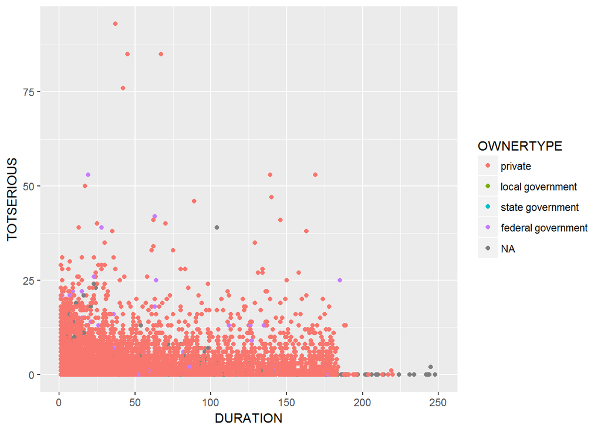

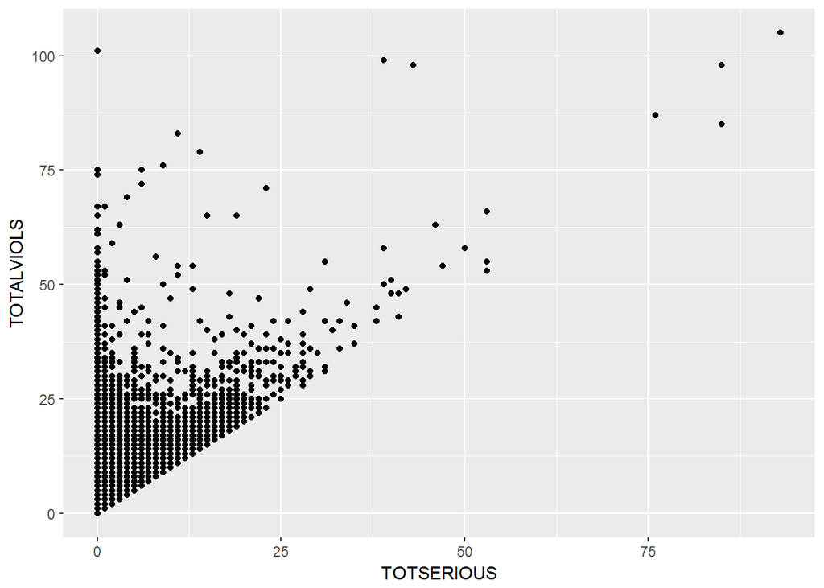

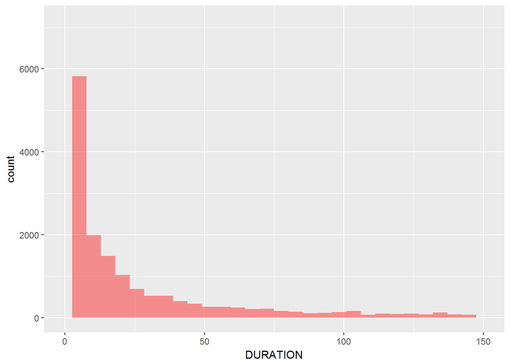

Save the cleaned data:

```r
o <- distinct(o)
write.dbf(o, file="osha1.dbf")
```

A table of the cleaned osha.dbf data

| OSHA1MOD | PREVCTTYP | ACTIVITYNO | ESTABNAME | SITEZIP | OWNERTYPE | OPENDATE | CLOSEDATE | UNION | PALITIGN | PASUMHOURS | PENREMIT | TOTPENLTY | TOTALVIOLS | TOTSERIOUS | INDUSTRY | CITY | PROG_INSPTYPE | UNPROG_INSPTYPE | DURATION |
| --- | --- | --- | --- | --- | --- | --- | --- | --- | --- | --- | --- | --- | --- | --- | --- | --- | --- | --- | --- |
| 1984-02-21 | NA | 10236776 | DUBE DRY WALL | 04074 | NA | 1983-12-15 | NA | N | 0 | 40 | 160 | 160 | 4 | 1 | PLASTERING, DRYWALL, AND INSULATION | SUNDERLAND | planned | NA | NA |
| 1991-05-23 | NA | 103393633 | KNOWLTON MACHINE CO. | 01970 | private | 1990-07-17 | 1990-07-20 | N | 0 | 360 | 1820 | 1820 | 5 | 4 | INDUSTRIAL MACHINERY, NEC | SALEM | NA | complaint | 3 |
| 1988-06-18 | NA | 18750034 | RENTAL & FROST | NA | NA | 1979-05-14 | 1979-05-14 | NA | 0 | NA | 0 | 0 | 0 | 0 | SHEET METAL WORK | BOSTON | NA | follow-up | NA |
| 1988-06-18 | NA | 18750042 | PENN TRUCK LINES | NA | NA | 1979-05-17 | 1979-05-17 | NA | 0 | NA | 0 | 0 | 0 | 0 | TRANSPORTATION SERVICES, NEC | BOSTON | NA | follow-up | NA |
| 1988-06-18 | NA | 18750059 | SILVERITE GUTT | NA | NA | 1979-07-10 | 1979-07-10 | NA | 0 | NA | 0 | 0 | 0 | 0 | FOOTWEAR CUT STOCK | BOSTON | NA | complaint | NA |
| 1988-06-18 | NA | 18750067 | MARSSON CORP | NA | NA | 1979-09-19 | 1979-09-19 | NA | 0 | NA | 0 | 0 | 0 | 0 | PAINTS AND ALLIED PRODUCTS | CHELSEA | NA | complaint | NA |
| 1988-06-18 | NA | 18750075 | HJP CONSTRUCTION CO | NA | NA | 1979-10-18 | 1979-10-18 | NA | 0 | NA | 0 | 0 | 0 | 0 | INDUSTRIAL BUILDINGS AND WAREHOUSES | CAMBRIDGE | planned | NA | NA |
| 1988-06-18 | NA | 18750083 | ANASTASI BROS | NA | NA | 1979-11-16 | 1979-11-16 | NA | 0 | NA | 0 | 0 | 0 | 0 | MASONRY AND OTHER STONE WORK | MEDFORD | NA | complaint | NA |
| 1988-06-18 | NA | 18750091 | CONSOLIDATED FREIGHTWAYS | NA | NA | 1979-11-21 | 1979-11-21 | NA | 0 | NA | 0 | 0 | 0 | 0 | TRUCKING, EXCEPT LOCAL | NORTH BILLERICA | NA | complaint | NA |
| 1988-06-18 | NA | 18750018 | ATLANTIC STEEL CO | NA | NA | 1980-03-18 | 1980-03-18 | NA | 0 | NA | 0 | 0 | 0 | 0 | METALS SERVICE CENTERS AND OFFICES | EVERETT | NA | complaint | NA |

# Part Two: Cleaning viol.dbf

Looking at all the variables for relevant ones: I will keep the following variables:

EMPHASIS - Value = X if case is egregious – I will have to change the coding for this variable  
GRAVITY - indicates level of potential harm, on a scale of 0 - 10  
PENCURRENT - current penalty OSHA has collected or intends to collect  
VIOLTYPE - current type of violation – change the coding of values  
STD - kind of violation (federal or state standard cited)  
INSTANCES - number of instances of violation of standard related event  
REC - related event code – I will use this to create a FATALITIES variable  
NUMEXPOSED - number of employees exposed to hazard  
DISPEVT - disposition of contested violation – make a variable for court decisions  
HAZCAT - Hazardous category

```r
v <- select(v, ACTIVITYNO, EMPHASIS, GRAVITY, PENCURRENT, INSTANCES, VIOLTYPE, STD, REC, NUMEXPOSED, DISPEVT, HAZCAT)
```

**1. Change coding of Emphasis:**

```r
levels(v$EMPHASIS)
```

```
## [1] "X"
```

```r
levels(v$EMPHASIS) <- c("egregious")
```

**2. Change coding of STD**

```r
colnames(lookSTD) <- c("STATE", "STD", "TEXT")
v <- left_join(v, lookSTD, by="STD")
v <- select(v, -STATE, -STD)
colnames(v)[11] <- "STD"
```

**3. Change coding of VIOLTYPE**

```r
levels(v$VIOLTYPE)
```

```
## [1] "O" "R" "S" "U" "W"
```

```r
levels(v$VIOLTYPE) <- c("other", "repeat", "serious", "unclassified", "willful")
```

**4. Change REC so that it only codes for fatalities**

```r
levels(v$REC)
```

```
##  [1] "1" "A" "B" "C" "D" "F" "I" "R" "S" "V"
```

```r
# Since the text file for VIOL does not give us information for some of the values in the data, I will only use the value assigned to fatality/catastrophe, as I think this represents the more dangerous workplaces.
levels(v$REC) <- c(NA, "Fatality/Catastrophe", NA, NA, NA, NA ,NA, NA, NA, NA)
colnames(v)[7] <- "FATALITY_CATASTROPHE"
```

**5. Change DISPEVT so that it only codes for court cases**

```r
levels(v$DISPEVT)
```

```
## [1] "2" "3" "D" "F" "J" "O" "R" "W"
```

```r
levels(v$DISPEVT) <- c("appeals court decision", "supreme court decision", "government dismissed case", "formal settlement agreement", "administrative law judge decision", NA, NA, NA)
```

**6. Change coding of GRAVITY**

```r
levels(v$GRAVITY)
```

```
##  [1] "00" "01" "02" "03" "04" "05" "06" "07" "08" "09" "10"
```

```r
levels(v$GRAVITY) <- c(0, 1, 2, 3, 4, 5, 6, 7, 8, 9, 10)
```

And finally, we save the file:

```r
v <- distinct(v)
write.dbf(v, file="violations.dbf")
```

A table of the cleaned viol.dbf data

| ACTIVITYNO | EMPHASIS | GRAVITY | PENCURRENT | INSTANCES | VIOLTYPE | FATALITY_CATASTROPHE | NUMEXPOSED | DISPEVT | HAZCAT | STD |
| --- | --- | --- | --- | --- | --- | --- | --- | --- | --- | --- |
| 10236776 | NA | NA | 160 | 1 | serious | NA | 0 | NA | NA | NA |
| 10236776 | NA | NA | 0 | 1 | other | NA | 0 | NA | NA | NA |
| 103393633 | NA | 7 | 490 | 1 | serious | NA | 10 | NA | NA | NA |
| 103393633 | NA | 8 | 560 | 1 | serious | NA | 10 | NA | NA | NA |
| 103393633 | NA | 6 | 420 | 1 | serious | NA | 10 | NA | NA | NA |
| 103393633 | NA | 5 | 350 | 1 | serious | NA | 20 | NA | NA | NA |
| 103393633 | NA | 1 | 0 | 1 | other | NA | 32 | NA | NA | NA |
| 10095883 | NA | NA | 0 | 2 | other | NA | 0 | NA | NA | NA |
| 10095883 | NA | NA | 0 | 1 | other | NA | 0 | NA | NA | NA |
| 10095826 | NA | NA | 180 | 1 | serious | NA | 0 | NA | NA | NA |

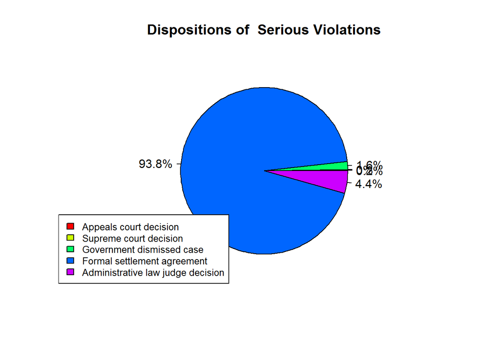

```r
set=subset(v, subset = VIOLTYPE == "serious")
summary <- set%>%
  group_by(DISPEVT)%>%
  tally
View(summary)
x <- c(16, 3, 121, 7264, 339)
label <- c("Appeals court decision", "Supreme court decision", "Government dismissed case", "Formal settlement agreement", "Administrative law judge decision")
piepercent <- round(100*x/sum(x), 1)
piepercent <- paste(piepercent, "%", sep="")
pie(x, labels=piepercent, col=rainbow(length(x)), main = "Dispositions of  Serious Violations")
legend("bottomleft", label, cex=0.8, fill=rainbow(length(x)))
```

# Part Three: Cleaning accid.dbf

Looking at all the variables for relevant ones: I will keep all the variables except for SITESTATE, NAME, and RELINSP.

```r
if(sum(a$SITESTATE=="MA")==dim(a)[1]){a%<>% select(-SITESTATE)}

a <- select(a, -NAME, -RELINSP)
```

**1. Change factors of DEGREE**

```r
# 1 - Change factors of DEGREE
levels(a$DEGREE)
```

```
## [1] "0" "1" "2" "3"
```

```r
levels(a$DEGREE) <- c("no injury", "fatality", "hospitalized", "non-hospitalized")
```

**2. NATURE of injury**

```r
levels(lookAcc$CATEGORY)
```

```
## [1] "ENVIR-FAC" "EVENT-TYP" "HUMAN-FAC" "NATUR-INJ" "PART-BODY" "SOURC-INJ"
```

```r
sum(lookAcc$CATEGORY=="NATUR-INJ")
```

```
## [1] 22
```

```r
levels(a$NATURE)
```

```
##  [1] "00" "01" "02" "03" "04" "05" "06" "07" "09" "10" "11" "12" "14" "15"
## [15] "16" "17" "18" "19" "20" "21"
```

```r
nature <- lookAcc[(lookAcc$CATEGORY == "NATUR-INJ"),]
dim(nature)
```

```
## [1] 22  3
```

```r
# Take CATEGORY out of new dataframe and change column names to join with accid.dbf
nature <- select(nature, CODE, VALUE)
colnames(nature) <- c("NATURE", "VALUE")
a <- left_join(a, nature, by = "NATURE")
# take out the column with the coding and rename the column with the values
a <- select(a, -NATURE)
colnames(a)[13] <- "NATURE"
```

**3. BODYPART**

```r
sum(lookAcc$CATEGORY=="PART-BODY")
```

```
## [1] 31
```

```r
levels(a$BODYPART)
```

```
##  [1] "00" "01" "02" "03" "04" "05" "06" "07" "08" "09" "10" "11" "12" "13"
## [15] "14" "15" "16" "17" "18" "19" "20" "21" "22" "23" "24" "25" "27" "28"
## [29] "29" "30" "31"
```

```r
parts <- lookAcc[(lookAcc$CATEGORY == "PART-BODY"),]

parts <- select(parts, CODE, VALUE)
colnames(parts) <- c("BODYPART", "VALUE")
a <- left_join(a, parts, by= "BODYPART")
a <- select(a, -BODYPART)
colnames(a)[13] <- "BODYPART"
```

**4. SOURCE of injury**

```r
sum(lookAcc$CATEGORY == "SOURC-INJ")
```

```
## [1] 48
```

```r
levels(a$SOURCE)
```

```
##  [1] "00" "01" "02" "04" "05" "06" "07" "08" "09" "10" "12" "13" "14" "15"
## [15] "16" "17" "18" "19" "21" "22" "23" "24" "25" "26" "27" "28" "29" "30"
## [29] "32" "34" "35" "36" "38" "39" "40" "41" "42" "43" "47"
```

```r
source <- lookAcc[(lookAcc$CATEGORY == "SOURC-INJ"),]

source <- select(source, CODE, VALUE)
colnames(source) <- c("SOURCE", "VALUE")
a <- left_join(a, source, by = "SOURCE")
a <- select(a, -SOURCE)
colnames(a)[13] <- "SOURCE"
```

**5. EVENT type**

```r
sum(lookAcc$CATEGORY == "EVENT-TYP")
```

```
## [1] 14
```

```r
levels(a$EVENT)
```

```
##  [1] "00" "01" "02" "03" "04" "05" "06" "07" "08" "09" "10" "11" "12" "13"
## [15] "14"
```

```r
events <- lookAcc[(lookAcc$CATEGORY == "EVENT-TYP"),]

events <- select(events, CODE, VALUE)
colnames(events) <- c("EVENT", "VALUE")
a <- left_join(a, events, by = "EVENT")
a <- select(a, -EVENT)
colnames(a)[13] <- "EVENT"
```

**6. ENVIRON - contributing factor**

```r
sum(lookAcc$CATEGORY == "ENVIR-FAC")
```

```
## [1] 18
```

```r
levels(a$ENVIRON)
```

```
##  [1] "00" "01" "02" "03" "04" "05" "06" "07" "08" "09" "10" "11" "12" "13"
## [15] "14" "15" "17" "18"
```

```r
environ <- lookAcc[(lookAcc$CATEGORY == "ENVIR-FAC"),]

environ <- select(environ, CODE, VALUE)
colnames(environ) <- c("ENVIRON", "VALUE")
a <- left_join(a, environ, by = "ENVIRON")

a <- select(a, -ENVIRON)
colnames(a)[13] <- "ENVIRON"
```

**7. HUMAN factor**

```r
sum(lookAcc$CATEGORY == "HUMAN-FAC")
```

```
## [1] 20
```

```r
levels(a$HUMAN)
```

```
##  [1] "00" "01" "02" "03" "04" "05" "06" "07" "08" "09" "10" "11" "12" "13"
## [15] "14" "15" "16" "17" "18" "19" "20"
```

```r
humanfac <- lookAcc[(lookAcc$CATEGORY == "HUMAN-FAC"),]

humanfac <- select(humanfac, CODE, VALUE)
colnames(humanfac) <- c("HUMAN", "VALUE")
a <- left_join(a, humanfac, by = "HUMAN")
a <- select(a, -HUMAN)
colnames(a)[13] <- "HUMAN"
```

**8. Change coding of TASK**

```r
levels(a$TASK)
```

```
## [1] "0" "1" "2"
```

```r
levels(a$TASK) <- c(NA, "regularly assigned task", "task other than regularly assigned")
```

**9. HAZSUB**

```r
colnames(lookhzs) <- c("HAZSUB", "VALUE")
a <- left_join(a, lookhzs, by = "HAZSUB")
a <- select(a, -HAZSUB)
colnames(a)[13] <- "HAZSUB"
```

**10. OCCUPATION**

```r
colnames(lookocc) <- c("OCC_CODE", "OCCUPATION")
a <- left_join(a, lookocc, by = "OCC_CODE")
a <- select(a, -OCC_CODE)
```

**11. Change age of 0 to NA**

```r
is.na(a$AGE) <- !a$AGE
```

And finally, save the file:

```r
a <- distinct(a)
write.dbf(a, file = "accidents.dbf")
```

A table of the cleaned accid.dbf

| ACTIVITYNO | SEX | DEGREE | TASK | AGE | NATURE | BODYPART | SOURCE | EVENT | ENVIRON | HUMAN | HAZSUB | OCCUPATION |
| --- | --- | --- | --- | --- | --- | --- | --- | --- | --- | --- | --- | --- |
| 10096592 | NA | non-hospitalized | task other than regularly assigned | NA | OTHER | BODYSYSTEM | FIRE/SMOKE | INHALATION | GAS/VAPOR/MIST/FUME/SMOKE/DUST | EQUIP. INAPPROPR FOR OPERATION | NA | NA |
| 305548745 | M | fatality | regularly assigned task | 47 | OTHER | MULTIPLE | ELEC APPARAT/WIRING | FALL(FROM ELEVATION) | OTHER | INSUF/LACK/PROTCV WRK CLTHG/EQUIP | NA | ELECTRICIANS |
| 306811928 | M | fatality | regularly assigned task | 39 | OTHER | NECK | OTHER | CAUGHT IN OR BETWEEN | OVERHEAD MOVING/FALLING OBJ AC | OTHER | NA | ELECTRICAL POWER INSTALLERS AND REPAIRERS |
| 306812744 | M | fatality | regularly assigned task | 22 | PUNCTURE | CHEST | HAND TOOL (POWERED) | OTHER | FLYING OBJECT ACTION | POSITION INAPROPRIATE FOR TASK | NA | CARPENTERS |
| 305545279 | M | fatality | regularly assigned task | 62 | OTHER | MULTIPLE | MACHINE | CAUGHT IN OR BETWEEN | MATERIALS HANDLG EQUIP./METHOD | MISJUDGMENT, HAZ. SITUATION | NA | NA |
| 306808122 | M | fatality | regularly assigned task | 47 | CONCUSSION | HEAD | AIR PRESSURE | STRUCK AGAINST | OVERPRESSURE/UNDERPRESSURE | MALFUNC IN SECURING/WARNING OP | NA | LABORERS, EXCEPT CONSTRUCTION |
| 10106342 | NA | fatality | regularly assigned task | NA | PUNCTURE | ABDOMEN | METAL PRODUCTS | CAUGHT IN OR BETWEEN | WORK-SURFACE/FACIL-LAYOUT COND | MATER-HANDLG PROCED. INAPPROPR | NA | NA |
| 10107019 | NA | fatality | regularly assigned task | NA | ASPHYXIA | HEAD | BOXES/BARRELS, ETC. | STRUCK BY | OVERHEAD MOVING/FALLING OBJ AC | NO PERSONAL PROTECTIVE EQ USED | NA | NA |
| 10107431 | NA | fatality | task other than regularly assigned | NA | ASPHYXIA | HEAD | MOTOR VEHICLE(INDUS) | STRUCK BY | OVERHEAD MOVING/FALLING OBJ AC | SAFETY DEVICES REMOVED/INOPER. | NA | NA |
| 10109288 | NA | fatality | task other than regularly assigned | NA | FRACTURE | HEAD | MOTOR VEHICLE (HWY) | CAUGHT IN OR BETWEEN | OVERHEAD MOVING/FALLING OBJ AC | SAFETY DEVICES REMOVED/INOPER. | NA | NA |

# Part 4: Joining all the datasets together

```r
finaldata <- left_join(o, v, by = "ACTIVITYNO")
finaldata <- left_join(finaldata, a, by = "ACTIVITYNO")


write.dbf(finaldata, file = "cleandata.dbf")
```

A table of the cleaned data

| OSHA1MOD | PREVCTTYP | ACTIVITYNO | ESTABNAME | SITEZIP | OWNERTYPE | OPENDATE | CLOSEDATE | UNION | PALITIGN | PASUMHOURS | PENREMIT | TOTPENLTY | TOTALVIOLS | TOTSERIOUS | INDUSTRY | CITY | PROG_INSPTYPE | UNPROG_INSPTYPE | DURATION | EMPHASIS | GRAVITY | PENCURRENT | INSTANCES | VIOLTYPE | FATALITY_CATASTROPHE | NUMEXPOSED | DISPEVT | HAZCAT | STD | … |
| --- | --- | --- | --- | --- | --- | --- | --- | --- | --- | --- | --- | --- | --- | --- | --- | --- | --- | --- | --- | --- | --- | --- | --- | --- | --- | --- | --- | --- | --- | --- |
| 1984-02-21 | NA | 10236776 | DUBE DRY WALL | 04074 | NA | 1983-12-15 | NA | N | 0 | 40 | 160 | 160 | 4 | 1 | PLASTERING, DRYWALL, AND INSULATION | SUNDERLAND | planned | NA | NA | NA | NA | 160 | 1 | serious | NA | 0 | NA | NA | NA | … |
| 1984-02-21 | NA | 10236776 | DUBE DRY WALL | 04074 | NA | 1983-12-15 | NA | N | 0 | 40 | 160 | 160 | 4 | 1 | PLASTERING, DRYWALL, AND INSULATION | SUNDERLAND | planned | NA | NA | NA | NA | 0 | 1 | other | NA | 0 | NA | NA | NA | … |
| 1991-05-23 | NA | 103393633 | KNOWLTON MACHINE CO. | 01970 | private | 1990-07-17 | 1990-07-20 | N | 0 | 360 | 1820 | 1820 | 5 | 4 | INDUSTRIAL MACHINERY, NEC | SALEM | NA | complaint | 3 | NA | 7 | 490 | 1 | serious | NA | 10 | NA | NA | NA | … |
| 1991-05-23 | NA | 103393633 | KNOWLTON MACHINE CO. | 01970 | private | 1990-07-17 | 1990-07-20 | N | 0 | 360 | 1820 | 1820 | 5 | 4 | INDUSTRIAL MACHINERY, NEC | SALEM | NA | complaint | 3 | NA | 8 | 560 | 1 | serious | NA | 10 | NA | NA | NA | … |
| 1991-05-23 | NA | 103393633 | KNOWLTON MACHINE CO. | 01970 | private | 1990-07-17 | 1990-07-20 | N | 0 | 360 | 1820 | 1820 | 5 | 4 | INDUSTRIAL MACHINERY, NEC | SALEM | NA | complaint | 3 | NA | 6 | 420 | 1 | serious | NA | 10 | NA | NA | NA | … |
| 1991-05-23 | NA | 103393633 | KNOWLTON MACHINE CO. | 01970 | private | 1990-07-17 | 1990-07-20 | N | 0 | 360 | 1820 | 1820 | 5 | 4 | INDUSTRIAL MACHINERY, NEC | SALEM | NA | complaint | 3 | NA | 5 | 350 | 1 | serious | NA | 20 | NA | NA | NA | … |
| 1991-05-23 | NA | 103393633 | KNOWLTON MACHINE CO. | 01970 | private | 1990-07-17 | 1990-07-20 | N | 0 | 360 | 1820 | 1820 | 5 | 4 | INDUSTRIAL MACHINERY, NEC | SALEM | NA | complaint | 3 | NA | 1 | 0 | 1 | other | NA | 32 | NA | NA | NA | … |
| 1988-06-18 | NA | 18750034 | RENTAL & FROST | NA | NA | 1979-05-14 | 1979-05-14 | NA | 0 | NA | 0 | 0 | 0 | 0 | SHEET METAL WORK | BOSTON | NA | follow-up | NA | NA | NA | NA | NA | NA | NA | NA | NA | NA | NA | … |
| 1988-06-18 | NA | 18750042 | PENN TRUCK LINES | NA | NA | 1979-05-17 | 1979-05-17 | NA | 0 | NA | 0 | 0 | 0 | 0 | TRANSPORTATION SERVICES, NEC | BOSTON | NA | follow-up | NA | NA | NA | NA | NA | NA | NA | NA | NA | NA | NA | … |
| 1988-06-18 | NA | 18750059 | SILVERITE GUTT | NA | NA | 1979-07-10 | 1979-07-10 | NA | 0 | NA | 0 | 0 | 0 | 0 | FOOTWEAR CUT STOCK | BOSTON | NA | complaint | NA | NA | NA | NA | NA | NA | NA | NA | NA | NA | NA | … |

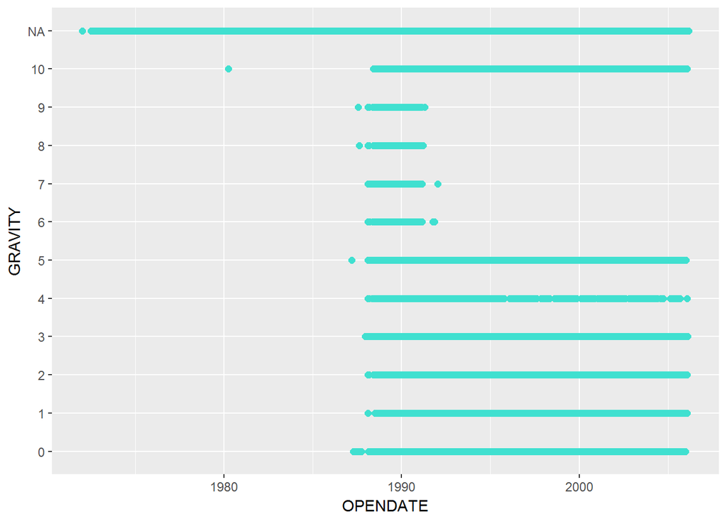

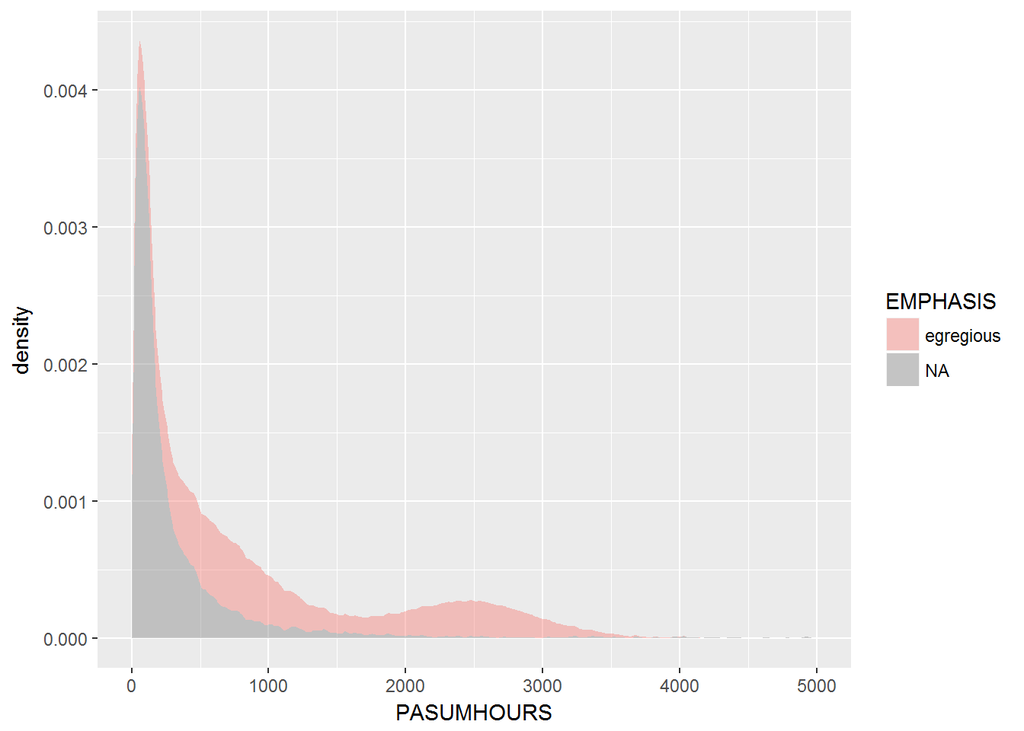